# Efectos del ChatGpt en el rendimiento académico de los estudiantes en UTEC

# 1 **INTRODUCCIÓN**

## 1.1 Contexto

En la actualidad, la tecnología ha transformado profundamente nuestra sociedad y se ha convertido en un recurso imprescindible en diversos ámbitos. En el contexto educativo, especialmente, se han desarrollado herramientas que permiten agilizar y optimizar distintas tareas académicas. La redacción de tesis, la elaboración de conclusiones, la resolución de problemas matemáticos y el resumen de textos son solo algunos ejemplos de las labores que pueden ser facilitadas mediante el uso de estas herramientas tecnológicas.

Una de estas herramientas es el ChatGPT, una aplicación basada en inteligencia artificial que permite resolver consultas y tareas académicas de manera expedita. Al utilizar algoritmos avanzados de procesamiento del lenguaje natural, el ChatGPT es capaz de comprender y generar respuestas coherentes a partir de las consultas que se le planteen.

La creciente aplicación de la inteligencia artificial, como la que se encuentra en el ChatGPT, en el ámbito educativo ha despertado el interés de investigadores y educadores. Se reconoce que estas herramientas tienen el potencial de ejercer una influencia significativa en el desempeño académico de los estudiantes. Sin embargo, también es crucial abordar y comprender los posibles efectos que su uso puede tener en el aprendizaje y desarrollo de habilidades.

En este contexto, se ha decidido llevar a cabo una investigación destinada a identificar los efectos potenciales del ChatGPT en el rendimiento académico de los estudiantes de UTEC. El objetivo principal de este estudio es analizar cómo el uso de esta herramienta tecnológica puede afectar el aprendizaje, la autonomía y las habilidades cognitivas de los estudiantes.

Mediante la recopilación de datos y la realización de encuestas, se espera obtener una visión más completa de la relación entre el uso del ChatGPT y el rendimiento académico de los estudiantes. Esto permitirá a la comunidad educativa tomar decisiones informadas sobre cómo aprovechar al máximo las ventajas de esta herramienta, promoviendo al mismo tiempo una formación integral y un desarrollo adecuado de las habilidades necesarias para el éxito académico y profesional.

## 1.2 Importancia

El ChatGPT puede ser una herramienta útil si se utiliza adecuadamente y de manera equilibrada, en conjunto con otras estrategias de aprendizaje, como la investigación, el estudio y la participación en clases. Su impacto en el rendimiento de un estudiante universitario en UTEC dependerá del uso que se le dé a la herramienta. Si se utiliza de manera adecuada, puede ser una herramienta eficaz para la investigación y el aprendizaje. Sin embargo, si un estudiante universitario depende demasiado del ChatGPT como una solución rápida para todas sus preguntas y tareas, podría tener un impacto negativo en su rendimiento académico a largo plazo.

Este estudio se ha originado con el objetivo de examinar el impacto del uso del ChatGPT en el rendimiento académico de los estudiantes universitarios de UTEC. Para tal fin, se llevará a cabo una encuesta efectiva, la cual permitirá la recolección de información y opiniones relevantes acerca del uso de esta herramienta. De este modo, será posible analizar detalladamente la relación entre el uso del ChatGPT y el desempeño académico de los estudiantes de UTEC.

Es importante destacar que el ChatGPT no debe reemplazar por completo otras habilidades y competencias académicas fundamentales, como la capacidad de investigación, el análisis crítico y la expresión escrita propia. El uso de esta herramienta debe ser complementario y servir como apoyo en el proceso de aprendizaje, fomentando la autonomía y el desarrollo de habilidades cognitivas.

Además, se espera que este estudio proporcione información valiosa para identificar posibles beneficios y desafíos asociados con el uso del ChatGPT en el contexto académico. Esto permitirá a la institución educativa tomar decisiones informadas sobre cómo integrar de manera efectiva esta herramienta en el proceso de enseñanza-aprendizaje y proporcionar orientación adecuada a los estudiantes para maximizar su rendimiento académico.

## 1.3 Objetivos

1. **Objetivo general**

Analizar la posible relación entre el uso de la inteligencia artificial, en particular el *ChatGpt*, y el rendimiento académico de los estudiantes de la Universidad de Ingeniería y Tecnología, a través de la obtención de información de múltiples estudiantes encuestados.

2. **Objetivos específicos**

2.1. Realizar una encuesta a una muestra de estudiantes universitarios de UTEC con el fin de identificar la frecuencia y el uso del *ChatGpt*, a fin de comprender cómo los estudiantes utilizan esta herramienta en su proceso de aprendizaje como universitarios.

2.2. Evaluar la percepción sobre la efectividad del *ChatGpt* como herramienta de aprendizaje, con el objetivo de comprender su influencia en la motivación de los estudiantes para utilizar la herramienta y su posible impacto en el rendimiento académico.

2.3. Ejecutar un análisis estadístico para identificar posibles correlaciones entre el uso del *ChatGpt* y el rendimiento académico de los estudiantes universitarios de UTEC, considerando las variables como la cantidad de tiempo dedicado al uso de la herramienta y los resultados obtenidos de la encuesta.

# 2 **DATOS**

## 2.1 Recolección de datos

La recolección de datos se llevó a cabo de manera sistemática y exhaustiva para garantizar la representatividad de la muestra. Se recopiló información sobre la cantidad de alumnos matriculados en cada carrera del semestre 2023-1.

A partir de esta información, se determinó la proporción de encuestados por carrera en base a un mínimo de 160 muestras. Se implementó una estrategia para compartir la encuesta entre los estudiantes, utilizando los grupos de cada carrera en plataformas como WhatsApp o correo. Se ofreció un incentivo para motivar a los alumnos a completar la encuesta y se les informó sobre la importancia de su participación en el estudio.

Inicialmente, se observó que la cantidad de muestras obtenidas era insuficiente para cumplir con los plazos establecidos. Ante esta situación, se decidió acelerar el proceso de recolección realizando encuestas de manera personal a los alumnos durante los días restantes. Se llevó a cabo un muestreo en diferentes pisos de la universidad, con mayor frecuencia en el piso 1, 6 y 11, donde suele haber una mayor concentración de estudiantes.

Es importante destacar que, a medida que se obtenía la cantidad de muestras requeridas para una carrera en particular, algunos compañeros continuaron completando la encuesta de forma virtual, sin ser conscientes de que ya se había alcanzado la cantidad necesaria. Esto resultó en una muestra total que excedió las 160 muestras inicialmente establecidas.

El equipo encargado de la recolección de datos trabajó de manera individual o en parejas, dependiendo de la disponibilidad de los integrantes. Se estableció un seguimiento constante del progreso de la recolección y se tomaron medidas para asegurar la calidad de los datos recopilados.

Toda esta información se tuvo en cuenta para garantizar la representatividad de la muestra y obtener resultados confiables en el análisis de los datos recopilados en el estudio.

## 2.2 Población, muestra y muestreo

Población: Estudiantes de UTEC matriculados en el semestre 2023-1.

Unidad muestral: Alumno de UTEC matriculado en el semestre 2023-1.

Muestreo: Para la recolección de datos, se optó por utilizar un método de muestreo por conveniencia, ya que se encuestaron alumnos en función de nuestra disponibilidad y consideraciones sobre la concentración de alumnos en ciertos pisos. Además, se incluyeron amigos y compañeros como parte de la muestra. Es importante tener en cuenta que este tipo de muestreo puede introducir cierto sesgo y limitar la representatividad de los resultados. Sin embargo, se tomaron medidas para minimizar los posibles sesgos y obtener la mayor cantidad de respuestas posibles.

## 2.3 Variables

| Variables | Descripción | Tipo |
| --- | --- | --- |
| Edad | Indica la edad de los estudiantes. | Variable numérica |
| Carrera | Representa la carrera universitaria de los estudiantes. | Variable categórica nominal |
| Sexo | Registra el género de los estudiantes. | Variable categórica nominal |
| Ciclo | Indica el ciclo académico en el que se encuentran los estudiantes. | Variable categórica ordinal |
| Conocimiento_ChatGPT | Refleja el nivel de conocimiento de los estudiantes sobre ChatGPT. | Variable numérico |
| Frecuencia_de_uso | Muestra la frecuencia de uso de ChatGPT por parte de los estudiantes. | Variable categórico ordinal |
| Horas_uso_diario | Indica la cantidad de horas diarias que los estudiantes utilizan ChatGPT. | Variable categórica ordinal |
| Obtencion_respuestas | Indica si los estudiantes obtienen respuestas a través de ChatGPT. | Variable categórica nominal |
| Tiempo_tareas_sin_ChatGPT | Muestra el tiempo que los estudiantes tardan en realizar tareas sin utilizar ChatGPT. | Variable categórica ordinal |
| Rendimiento_academico_SIN_ChatGPT | Refleja el rendimiento académico de los estudiantes sin utilizar ChatGPT. | Variable categórica ordinal |
| Nota_promedio_TAREAS_SIN_ChatGPT | Representa la nota promedio de las tareas de los estudiantes sin utilizar ChatGPT. | Variable numérica |
| Tiempo_tareas_CON_ChatGPT | Muestra el tiempo que los estudiantes tardan en realizar tareas utilizando ChatGPT. | Variable categórica ordinal |
| Notas_CON_ChatGPT | Refleja el impacto de utilizar ChatGPT en las notas de los estudiantes. | Variable categórica nominal |
| Nota_promedio_CON_ChatGPT | Representa la nota promedio de los estudiantes utilizando ChatGPT. | Variable numérica |
| Aprendizaje_CON_ChatGPT | Indica la percepción del aprendizaje de los estudiantes utilizando ChatGPT. | Variable categórica ordinal |

## 2.4 Limpieza de base de datos

Antes de continuar, primero haremos una pequeña limpieza de nuestro dataframe. Como indicamos anteriormente, nuestra base de datos la obtuvimos mediante una encuesta. Esta encuesta tenía, originalmente, columnas que no eran variables precisamente. Tales columnas eran generadas automáticamente al momento de descargar nuestro dataframe en formato CSV. Además, había algunas columnas creadas por el equipo encargado de realizar la encuesta que no eran precisamente variables, sino más bien preguntas que nos servirían de apoyo para un estudio más preciso. Dichas columnas eran preguntas opcionales que, junto con las columnas generadas automáticamente, preferimos eliminar para trabajar con un dataframe limpio y solo con las variables que analizaremos en nuestro estudio.

```r
#Primero cargamos nuestras librerías necesarias
library(readr)
library(plyr)
library(dplyr)
library(tidyr)
library(tidyverse)
```

```r
library(ggplot2)
library(plotly)
library(plotrix)
library(tidyverse)
library(DT)
library(ggalt)
library(RColorBrewer)
#Ahora estableceremos nuestro DataBase para trabajar en Rstudio
DB <- read_csv("DBvol2.0.csv")
```

La primera parte de la limpieza es, en realidad, una mejora que hemos considerado para trabajar con nuestras variables. Debido a la encuesta, nuestras variables tenían nombres largos y específicos, que daban a entender qué era lo que los encuestados respondían. Esto se puede apreciar en el siguiente código:

```r
names(DB)
```

```
##  [1] "Marca temporal"
##  [2] "Número de celular para participar del sorteo"
##  [3] "¿Cuántos años tienes?"
##  [4] "¿De qué carrera eres?"
##  [5] "Selecciona tu género"
##  [6] "¿Qué ciclo estas cursando actualmente?"
##  [7] "¿Qué tanto te sientes familiarizado con el sistema de inteligencia artificial - Chat GPT? \n1: Para nada familiarizado\n10: Soy experto en ChatGPT"
##  [8] "¿Con qué frecuencia usas \"Chat GPT\" en tu dia a dia?"
##  [9] "¿Cuantas horas de uso le das a ChatGPT al dia?"
## [10] "¿Siempre obtienes la respuesta que esperas o buscas en \"ChatGPT\"?"
## [11] "¿Cuánto tiempo te toma hacer tus tareas en general, SIN usar \"ChatGPT\"?"
## [12] "¿Cómo solian ser tus notas y tu rendimiento academico antes de que existiera \"ChatGPT\"?"
## [13] "Con respecto a la pregunta anterior. ¿Por qué? (OPCIONAL)...13"
## [14] "¿Cuánto de nota promedio sacabas o sacas en tus quizzes o tareas semanales en un Rango de 0 a 20 sin el uso de \"Chat GPT\"? Menciona una nota promedio aproximada."
## [15] "¿Qué tiempo aproximadamente empleas para realizar tareas con el uso de \"Chat GPT\"?"
## [16] "Actualmente, ¿Cómo te va con tus tareas y notas con el uso de ChatGPT?"
## [17] "Con respecto a la pregunta anterior. ¿Por qué? (OPCIONAL)...17"
## [18] "Actualmente ¿Cuánto de nota promedio sacas en tus quizzes o tareas semanales en un Rango de 0 a 20 con el uso de \"Chat GPT\"? Menciona una nota promedio aproximada y considera todos los cursos en los que podrias usar ChatGPT."
## [19] "Responder con sinceridad, ¿Realmente crees que aprendes al usar \"ChatGPT\"? ¿Solo lo usas para que haga tus tareas, sin intentarlo tu mismo?"
```

Como vemos, los nombres de las variables son muy largos. Para cambiar y reducir esto, realizamos el siguiente cambio de nombres de variables, que es algo más simple y comprensible para facilitar el trabajo:

```r
DB2 <-rename(DB, Edad= "¿Cuántos años tienes?",
               Carrera="¿De qué carrera eres?",
               Sexo="Selecciona tu género",
               Ciclo="¿Qué ciclo estas cursando actualmente?",
               Conocimiento_ChatGPT="¿Qué tanto te sientes familiarizado con el sistema de inteligencia artificial - Chat GPT? \n1: Para nada familiarizado\n10: Soy experto en ChatGPT" ,
               Frecuencia_de_uso="¿Con qué frecuencia usas \"Chat GPT\" en tu dia a dia?",
               Horas_uso_diario="¿Cuantas horas de uso le das a ChatGPT al dia?",
               Obtencion_respuestas="¿Siempre obtienes la respuesta que esperas o buscas en \"ChatGPT\"?",
               Tiempo_tareas_sin_ChatGPT ="¿Cuánto tiempo te toma hacer tus tareas en general, SIN usar \"ChatGPT\"?",
               Rendimiento_academico_SIN_ChatGPT="¿Cómo solian ser tus notas y tu rendimiento academico antes de que existiera \"ChatGPT\"?",
               Nota_promedio_TAREAS_SIN_ChatGPT="¿Cuánto de nota promedio sacabas o sacas en tus quizzes o tareas semanales en un Rango de 0 a 20 sin el uso de \"Chat GPT\"? Menciona una nota promedio aproximada.",

               Tiempo_tareas_CON_ChatGPT="¿Qué tiempo aproximadamente empleas para realizar tareas con el uso de \"Chat GPT\"?",
               Notas_CON_ChatGPT="Actualmente, ¿Cómo te va con tus tareas y notas con el uso de ChatGPT?",
               Nota_promedio_CON_ChatGPT= "Actualmente ¿Cuánto de nota promedio sacas en tus quizzes o tareas semanales en un Rango de 0 a 20 con el uso de \"Chat GPT\"? Menciona una nota promedio aproximada y considera todos los cursos en los que podrias usar ChatGPT.",
               Aprendizaje_CON_ChatGPT="Responder con sinceridad, ¿Realmente crees que aprendes al usar \"ChatGPT\"? ¿Solo lo usas para que haga tus tareas, sin intentarlo tu mismo?")
```

Ahora sí, podemos trabajar con unos nombres mas limpios y claros:

```r
names(DB2)
```

```
##  [1] "Marca temporal"
##  [2] "Número de celular para participar del sorteo"
##  [3] "Edad"
##  [4] "Carrera"
##  [5] "Sexo"
##  [6] "Ciclo"
##  [7] "Conocimiento_ChatGPT"
##  [8] "Frecuencia_de_uso"
##  [9] "Horas_uso_diario"
## [10] "Obtencion_respuestas"
## [11] "Tiempo_tareas_sin_ChatGPT"
## [12] "Rendimiento_academico_SIN_ChatGPT"
## [13] "Con respecto a la pregunta anterior. ¿Por qué? (OPCIONAL)...13"
## [14] "Nota_promedio_TAREAS_SIN_ChatGPT"
## [15] "Tiempo_tareas_CON_ChatGPT"
## [16] "Notas_CON_ChatGPT"
## [17] "Con respecto a la pregunta anterior. ¿Por qué? (OPCIONAL)...17"
## [18] "Nota_promedio_CON_ChatGPT"
## [19] "Aprendizaje_CON_ChatGPT"
```

A partir de aqui empezaria nuestra limpieza como tal, pues eliminaremos las columnas que no entran en nuestros objetivos de análisis:

```r
DB3<-DB2%>%select(-c(1,2,13,17))
```

Ahora nuestras únicas variables con los nombres reducidos quedaría de la siguiente manera:

```r
names(DB3)
```

```
##  [1] "Edad"                              "Carrera"
##  [3] "Sexo"                              "Ciclo"
##  [5] "Conocimiento_ChatGPT"              "Frecuencia_de_uso"
##  [7] "Horas_uso_diario"                  "Obtencion_respuestas"
##  [9] "Tiempo_tareas_sin_ChatGPT"         "Rendimiento_academico_SIN_ChatGPT"
## [11] "Nota_promedio_TAREAS_SIN_ChatGPT"  "Tiempo_tareas_CON_ChatGPT"
## [13] "Notas_CON_ChatGPT"                 "Nota_promedio_CON_ChatGPT"
## [15] "Aprendizaje_CON_ChatGPT"
```

En esta parte corregimos y creamos nuevas variables a partir de nuestras variables originales. Esta limpieza se debe a diversos factores. Por ejemplo, al momento de crear la encuesta, hubo un error en la variable “carreras” donde se repetían carreras como opciones de respuesta. Otro factor fue dado por nuestra asesora de proyecto, Fiorela Calderón, quien nos recomendó reducir nuestras opciones de respuesta en la variable “Conocimiento de ChatGPT”. Inicialmente, proporcionábamos un rango de respuestas del 1 al 10. Todo lo demás son casos similares:

```r
DB4<-mutate(DB3, Carrera_cor=case_when(Carrera=="Administración y Negocios Digitales"~"Administración y Negocios Digitales", Carrera=="Bioingeniería"~"Bioingeniería", Carrera=="Ciencia de Datos"~"Ciencia de Datos (CS)", Carrera=="Ciencia de Datos (CS)"~"Ciencia de Datos (CS)", Carrera=="DIngeniería ambiental"~"Ingeniería ambiental", Carrera=="Ingeniería ambiental"~"Ingeniería ambiental", Carrera=="Ingeniería Civil"~"Ingeniería Civil", Carrera=="Ingeniería electrónica"~"Ingeniería electrónica", Carrera=="Ingeniería Industrial"~"Ingeniería Industrial", Carrera=="Ingeniería Mecánica"~"Ingeniería Mecánica", Carrera=="Ingeniería Mecatrónica"~"Ingeniería Mecatrónica", Carrera=="Ingeniería Química"~"Ingeniería Química"))
```

```r
DB4<-mutate(DB4, Conocimiento_ChatGPT_cor=case_when(Conocimiento_ChatGPT=="1"~"1", Conocimiento_ChatGPT=="2"~"1", Conocimiento_ChatGPT=="3"~"1", Conocimiento_ChatGPT=="4"~"2", Conocimiento_ChatGPT=="5"~"2", Conocimiento_ChatGPT=="6"~"2", Conocimiento_ChatGPT=="7"~"2", Conocimiento_ChatGPT=="8"~"3", Conocimiento_ChatGPT=="9"~"3", Conocimiento_ChatGPT=="10"~"3"))
```

```r
DB4<-mutate(DB4, Obtencion_respuestas_cor=case_when(Obtencion_respuestas=="Aveces"~"A veces", Obtencion_respuestas=="A veces"~"A veces", Obtencion_respuestas=="Sí"~"Sí", Obtencion_respuestas=="No"~"No"))
```

```r
DB4<-mutate(DB4, Tiempo_tareas_CON_ChatGPT_cor=case_when(Tiempo_tareas_CON_ChatGPT=="0"~"No uso", Tiempo_tareas_CON_ChatGPT=="00"~"No uso", Tiempo_tareas_CON_ChatGPT=="Nada porque no uso"~"No uso", Tiempo_tareas_CON_ChatGPT=="No lo usé para tareas hasta ahora"~"No uso", Tiempo_tareas_CON_ChatGPT=="No lo uso"~"No uso", Tiempo_tareas_CON_ChatGPT=="No lo uso para tareas, solo para información"~"No uso", Tiempo_tareas_CON_ChatGPT=="no uso"~"No uso", Tiempo_tareas_CON_ChatGPT=="No uso"~"No uso", Tiempo_tareas_CON_ChatGPT=="No uso charGPT"~"No uso", Tiempo_tareas_CON_ChatGPT=="no uso chat gpt"~"No uso", Tiempo_tareas_CON_ChatGPT=="No uso chat gpt"~"No uso", Tiempo_tareas_CON_ChatGPT=="No uso Chat GPT"~"No uso", Tiempo_tareas_CON_ChatGPT=="No uso ChatGPT"~"No uso", Tiempo_tareas_CON_ChatGPT=="No uso el chatGTP"~"No uso", Tiempo_tareas_CON_ChatGPT=="No uso xd"~"No uso", Tiempo_tareas_CON_ChatGPT=="no utilizo"~"No uso", Tiempo_tareas_CON_ChatGPT=="Nunca"~"No uso", Tiempo_tareas_CON_ChatGPT=="Un par de minutos."~"1 hora", Tiempo_tareas_CON_ChatGPT=="1 hora"~"1 hora", Tiempo_tareas_CON_ChatGPT=="Menos de 1 hora"~"1 hora", Tiempo_tareas_CON_ChatGPT=="2 horas"~"2 horas", Tiempo_tareas_CON_ChatGPT=="3 horas"~"Más de 3 horas", Tiempo_tareas_CON_ChatGPT=="Más de 3 horas"~"Más de 3 horas"))
```

```r
# Verificar el valor actual en la fila 111 de la columna "Notas_CON_ChatGPT"
DB4[111, "Nota_promedio_CON_ChatGPT"]
```

```
## # A tibble: 1 x 1
##   Nota_promedio_CON_ChatGPT
##                       <dbl>
## 1                       111
```

```r
# Corregir el valor de la nota en la fila 111 de la columna "Notas_CON_ChatGPT"
DB4[111, "Nota_promedio_CON_ChatGPT"] <- 11
# Verificar que se haya corregido correctamente
DB4[111, "Nota_promedio_CON_ChatGPT"]
```

```
## # A tibble: 1 x 1
##   Nota_promedio_CON_ChatGPT
##                       <dbl>
## 1                        11
```

```r
DB4<-mutate(DB4,Horas_uso_diario_cor=case_when(Horas_uso_diario=="No uso"~"No uso", Horas_uso_diario=="Menos de 1 hora"~"1 hora", Horas_uso_diario=="1 hora"~"1 hora", Horas_uso_diario=="2 horas"~"2 horas", Horas_uso_diario=="3 horas"~"3 horas",
Horas_uso_diario=="4 horas"~"4 hora",
Horas_uso_diario=="5 horas"~"5 horas",
Horas_uso_diario=="6 horas"~"Más de 5 horas",
Horas_uso_diario=="7 horas"~"Más de 5 horas",
Horas_uso_diario=="Todo el dia"~"Más de 5 horas"))
```

En esta ultima sección de limpieza de base de datos, eliminamos las columnas originales para solo quedarnos con nuestras nuevas columnas corregidas, donde finalmente nos quedaremos y trabajaremos con nuestro dataframe DB4:

```r
DB4$Obtencion_respuestas <-NULL
DB4$Horas_uso_diario <-NULL
DB4$Conocimiento_ChatGPT <-NULL
DB4$Carrera<-NULL
DB4$Tiempo_tareas_CON_ChatGPT<-NULL
```

# 3 **ANALISIS DESCRIPTIVO**

## 3.1 Relación entre la carrera y el rendimiento académico:

Se considera esta relación debido a que diferentes carreras pueden tener diferentes niveles de dificultad, enfoques de estudio y requisitos académicos. Analizar esta relación puede ayudar a determinar si hay diferencias significativas en el rendimiento académico entre las carreras. Esto podría indicar si la carrera en sí misma influye en el rendimiento o si hay otros factores en juego.

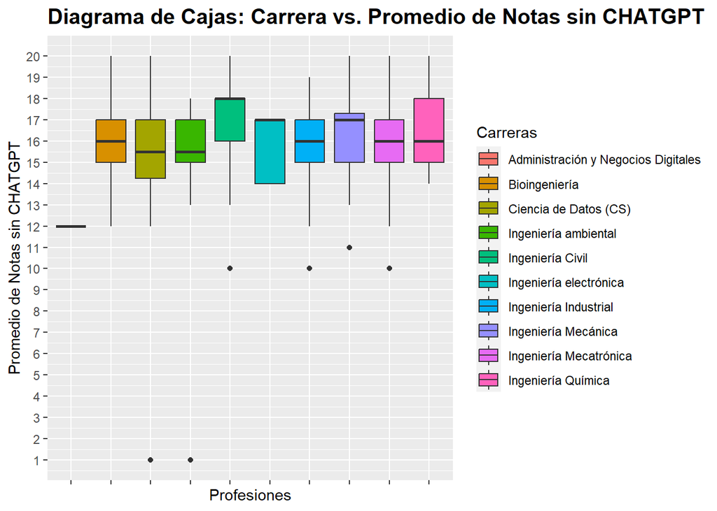

```r
ggplot(DB4, aes(x = Carrera_cor, y = Nota_promedio_TAREAS_SIN_ChatGPT, fill=Carrera_cor)) +
  geom_boxplot() +
  xlab("Profesiones") +
  ylab("Promedio de Notas sin CHATGPT") +
  ggtitle("Diagrama de Cajas: Carrera vs. Promedio de Notas sin CHATGPT")+
  theme(plot.title = element_text(face = "bold", size = 15, family = "Arial", vjust = +1)) +
  theme(axis.text.x = element_blank()) +
  labs(fill = "Carreras") +
  scale_y_continuous(breaks = seq(min(DB4$Nota_promedio_TAREAS_SIN_ChatGPT), max(DB4$Nota_promedio_TAREAS_SIN_ChatGPT), by = 1))
```

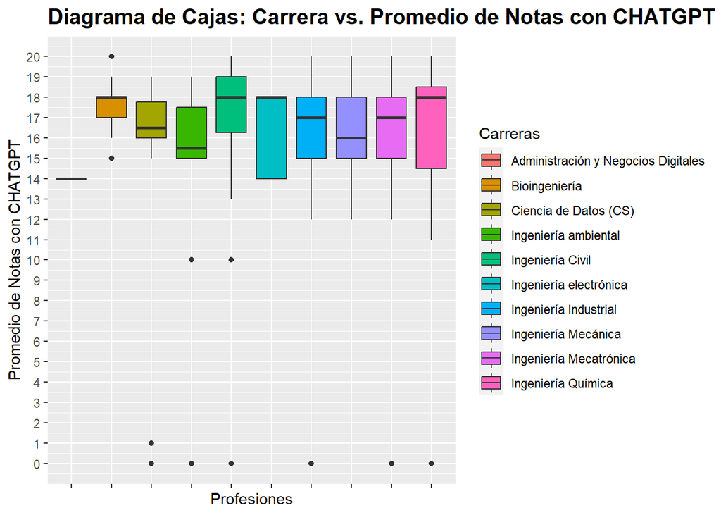

```r
ggplot(DB4, aes(x = Carrera_cor, y = Nota_promedio_CON_ChatGPT, fill=Carrera_cor)) +
  geom_boxplot() +
  xlab("Profesiones") +
  ylab("Promedio de Notas con CHATGPT") +
  ggtitle("Diagrama de Cajas: Carrera vs. Promedio de Notas con CHATGPT")+
  theme(plot.title = element_text(face = "bold", size = 15, family = "Arial", vjust = +1)) +
  theme(axis.text.x = element_blank()) +
  labs(fill = "Carreras") +
  scale_y_continuous(breaks = seq(min(DB4$Nota_promedio_CON_ChatGPT), max(DB4$Nota_promedio_CON_ChatGPT), by = 1))
```

```r
table(DB4$Carrera_cor, DB4$Ciclo)
```

```
##
##                                       10mo ciclo 1er ciclo 2do ciclo 3er ciclo
##   Administración y Negocios Digitales          0         0         0         1
##   Bioingeniería                                0         0         1         9
##   Ciencia de Datos (CS)                        0         1         2         4
##   Ingeniería ambiental                         0         0         0         2
##   Ingeniería Civil                             0         0         7         6
##   Ingeniería electrónica                       0         1         1         3
##   Ingeniería Industrial                        4         3         3        14
##   Ingeniería Mecánica                          1         2         1        10
##   Ingeniería Mecatrónica                       0         8         5        10
##   Ingeniería Química                           0         1         2         4
##
##                                       4to ciclo 5to ciclo 6to ciclo 7mo ciclo
##   Administración y Negocios Digitales         0         0         0         0
##   Bioingeniería                               1         0         0         1
##   Ciencia de Datos (CS)                       2         4         0         1
##   Ingeniería ambiental                        7         1         0         0
##   Ingeniería Civil                            7         2         0         0
##   Ingeniería electrónica                      0         0         0         0
##   Ingeniería Industrial                      11         1         0         3
##   Ingeniería Mecánica                         3         2         0         1
##   Ingeniería Mecatrónica                      2         2         2         0
##   Ingeniería Química                          1         2         1         0
##
##                                       8vo ciclo
##   Administración y Negocios Digitales         0
##   Bioingeniería                               1
##   Ciencia de Datos (CS)                       0
##   Ingeniería ambiental                        0
##   Ingeniería Civil                            0
##   Ingeniería electrónica                      0
##   Ingeniería Industrial                       0
##   Ingeniería Mecánica                         1
##   Ingeniería Mecatrónica                      0
##   Ingeniería Química                          0
```

## 3.2 Frecuencia de uso - Nota promedio con ChatGPT

Esta relación se considera para determinar si existe una asociación entre la frecuencia de uso de ChatGPT y el rendimiento académico. Se espera que aquellos estudiantes que utilizan ChatGPT con mayor frecuencia obtengan mejores resultados académicos, ya que pueden acceder a respuestas y ayuda de manera más regular. El análisis puede proporcionar información sobre cómo la frecuencia de uso de ChatGPT se relaciona con el rendimiento académico y si hay una tendencia o patrón identificable.

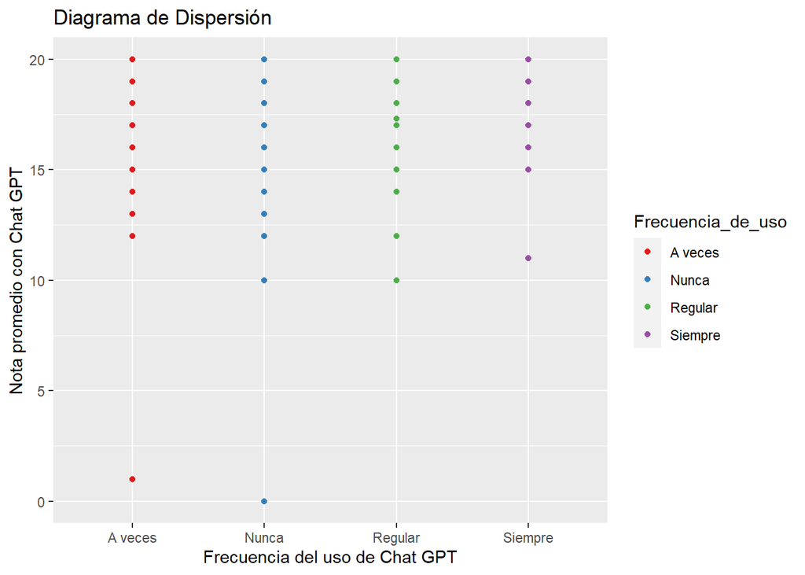

```r
DB4$Nota_promedio_CON_ChatGPT <- ifelse(DB4$Nota_promedio_CON_ChatGPT>20, 20, DB4$Nota_promedio_CON_ChatGPT)

colores <- brewer.pal(n = length(unique(DB4$Frecuencia_de_uso)), name = "Set1")

ggplot(DB4, aes(x = Frecuencia_de_uso, y = Nota_promedio_CON_ChatGPT, color = Frecuencia_de_uso)) +
  geom_point() +
  scale_color_manual(values = colores) +
  labs(x = "Frecuencia del uso de Chat GPT", y = "Nota promedio con Chat GPT", title = "Diagrama de Dispersión")
```

## 3.3 Tiempo tarea con chatGPT - Nota promedio con ChatGPT

Se exploró esta relación para determinar si el tiempo dedicado a realizar tareas con la ayuda de ChatGPT está relacionado con el rendimiento académico. Es posible que aquellos estudiantes que invierten más tiempo en el uso de la herramienta logren mejores resultados, ya que pueden obtener una mayor comprensión y profundidad en sus tareas. El análisis puede proporcionar información sobre cómo el tiempo dedicado a utilizar ChatGPT se relaciona con el rendimiento académico y si existe una correlación significativa.

```r
mean(DB4$Nota_promedio_CON_ChatGPT)
```

```
## [1] 16.03212
```

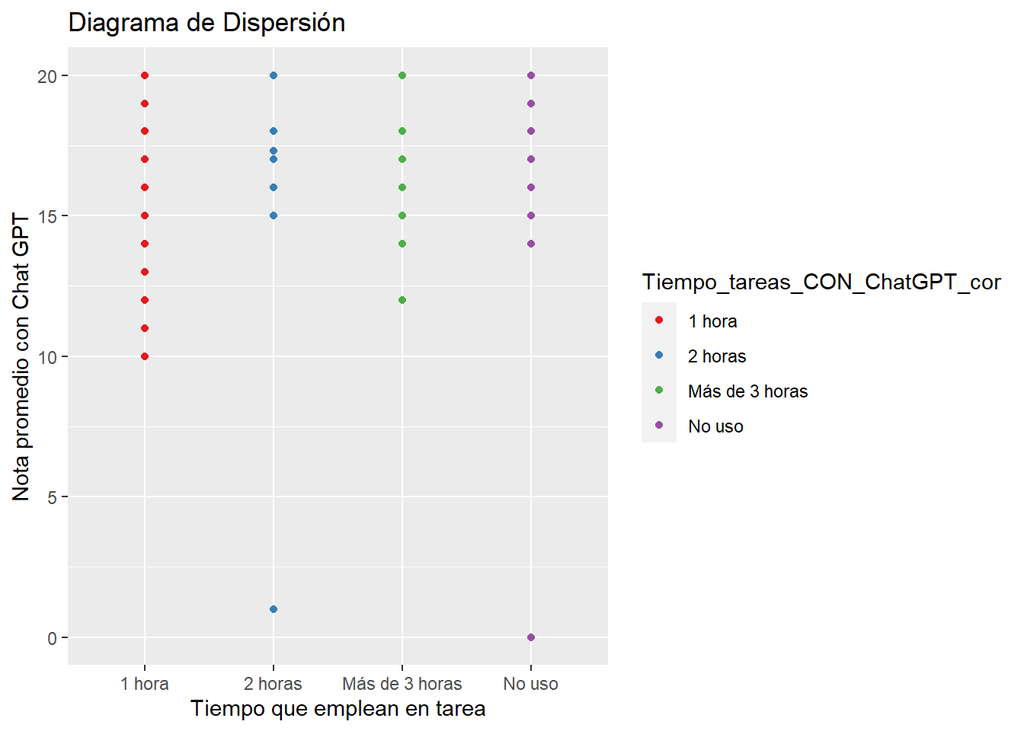

```r
colores <- brewer.pal(n = length(unique(DB4$Tiempo_tareas_CON_ChatGPT_cor)), name = "Set1")

ggplot(DB4, aes(x = Tiempo_tareas_CON_ChatGPT_cor, y = Nota_promedio_CON_ChatGPT, color = Tiempo_tareas_CON_ChatGPT_cor)) +
  geom_point() +
  scale_color_manual(values = colores) +
  labs(x = "Tiempo que emplean en tarea", y = "Nota promedio con Chat GPT", title = "Diagrama de Dispersión")
```

## 3.4 Relación entre el conocimiento del uso de ChatGPT y el rendimiento académico

Se exploró esta relación porque se espera que aquellos estudiantes que tienen un mayor conocimiento del uso de ChatGPT puedan aprovechar mejor esta herramienta y obtener mejores resultados académicos. El análisis puede revelar si el conocimiento previo del uso de ChatGPT tiene un impacto en el rendimiento académico, y si aquellos que ya están familiarizados con la herramienta tienen un rendimiento superior en comparación con los que no lo están.

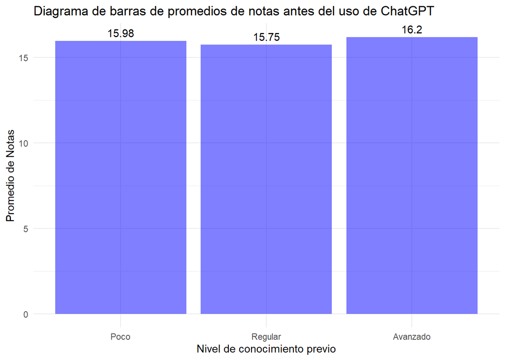

```r
promedios <- DB4 %>%
  group_by(Conocimiento_ChatGPT_cor) %>%
  summarize(Promedio_Antes = mean(Nota_promedio_TAREAS_SIN_ChatGPT, na.rm = TRUE),
            Promedio_Despues = mean(Nota_promedio_CON_ChatGPT, na.rm = TRUE))


promedios$Conocimiento_ChatGPT_cor <- factor(promedios$Conocimiento_ChatGPT_cor,
                                             levels = c(1, 2, 3),
                                             labels = c("Poco", "Regular", "Avanzado"))

ggplot(promedios, aes(x = Conocimiento_ChatGPT_cor, y = Promedio_Antes)) +
  geom_bar(stat = "identity", fill = "blue", alpha = 0.5) +
  geom_text(aes(label = round(Promedio_Antes, 2)), vjust = -0.5, color = "black")+
  labs(title = "Diagrama de barras de promedios de notas antes del uso de ChatGPT",
       x = "Nivel de conocimiento previo",
       y = "Promedio de Notas") +
  theme_minimal()
```

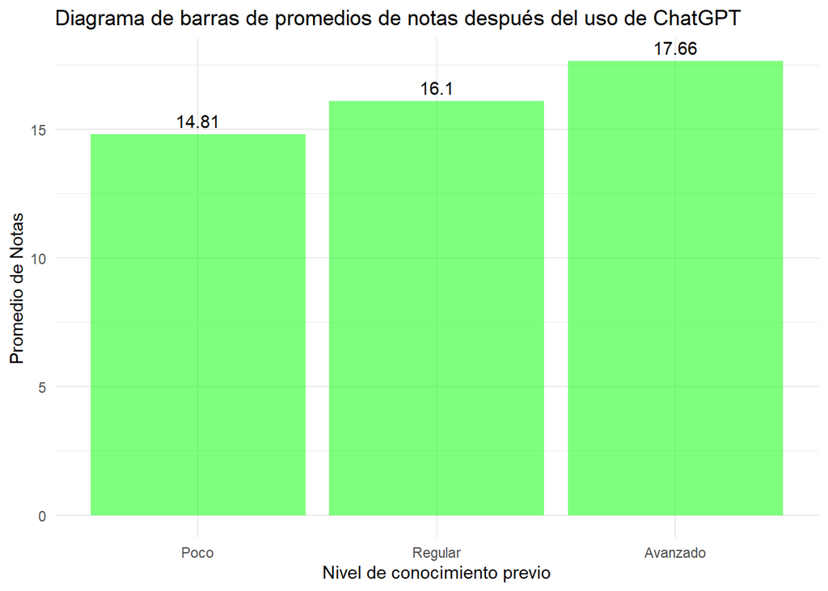

```r
ggplot(promedios, aes(x = Conocimiento_ChatGPT_cor, y = Promedio_Despues)) +
  geom_bar(stat = "identity", fill = "green", alpha = 0.5) +
  geom_text(aes(label = round(Promedio_Despues, 2)), vjust = -0.5, color = "black") +
  labs(title = "Diagrama de barras de promedios de notas después del uso de ChatGPT",
       x = "Nivel de conocimiento previo",
       y = "Promedio de Notas") +
  theme_minimal()
```

Este cambio en los promedios se debe al factor de obtener notas bajas y altas después de conocer ChatGPT. La inteligencia artificial desarrollada por OpenAI, ChatGPT, brinda respuestas precisas cuando se le dan instrucciones precisas. De lo contrario, no proporcionará los resultados esperados. Además, aquellos que obtienen notas bajas indicaron tener poco conocimiento sobre ChatGPT, mientras que aquellos con notas altas indicaron tener un conocimiento avanzado.

En resumen, cuanto más conocimiento se tenga sobre ChatGPT y se le den instrucciones adecuadas, se obtendrán los resultados esperados.

**Realizar la prueba t de Student**

```r
resultado_prueba_t <- t.test(DB4$Nota_promedio_TAREAS_SIN_ChatGPT, DB4$Nota_promedio_CON_ChatGPT)
```

**Obtener las estadísticas de interés**

```r
estadisticas <- c(Diferencia_Medias = resultado_prueba_t$estimate,
                  Valor_p = resultado_prueba_t$p.value,
                  Intervalo_Confianza = c(resultado_prueba_t$conf.int[1], resultado_prueba_t$conf.int[2]))

estadisticas
```

```
## Diferencia_Medias.mean of x Diferencia_Medias.mean of y
##                  15.9018182                  16.0321212
##                     Valor_p        Intervalo_Confianza1
##                   0.7225640                  -0.8519705
##        Intervalo_Confianza2
##                   0.5913644
```

El resultado indica lo siguiente:

- *Diferencia_Medias.mean of x: La diferencia media de las notas antes del uso de ChatGPT.*
- *Diferencia_Medias.mean of y: La diferencia media de las notas después del uso de ChatGPT.*
- *Valor_p: El valor p asociado a la prueba t de Student, que indica la probabilidad de obtener una diferencia media tan extrema o más extrema que la observada, si no hay diferencia real entre los grupos.*
- *Intervalo_Confianza1: El límite inferior del intervalo de confianza del 95% para la diferencia de medias.*
- *Intervalo_Confianza2: El límite superior del intervalo de confianza del 95% para la diferencia de medias.*

Los promedios de las variables x e y son 15.9018182 y 16.0321212 respectivamente. El valor p obtenido en la prueba estadística indica que no hay evidencia significativa para rechazar la hipótesis nula. El intervalo de confianza sugiere que la diferencia entre las medias de x e y se encuentra entre -0.8519705 y 0.5913644.

## 3.5 Relación entre las notas antes de ChatGPT y el rendimiento académico actual

Se considera esta relación para evaluar si hay un cambio en el rendimiento académico después de la introducción de ChatGPT. Al comparar las notas antes de la existencia de ChatGPT con el rendimiento actual, se puede analizar si la herramienta ha tenido un impacto positivo o negativo en el rendimiento de los estudiantes. El análisis puede proporcionar información sobre las mejoras o posibles deficiencias que puede tener el uso de ChatGPT en el rendimiento académico.

```r
# Crear un data frame con las frecuencias
frecuencia_anterior <- table(DB4$Rendimiento_academico_SIN_ChatGPT)
frecuencia_actual <- table(DB4$Notas_CON_ChatGPT)
df <- data.frame(Categoría = c(names(frecuencia_anterior), names(frecuencia_actual)),
                 Antes_ChatGPT = c(frecuencia_anterior ),
                 Con_ChatGPT = c(frecuencia_actual))
frecuencia_anterior
```

```
##
##            Mis notas eran muy malas, no entrega tareas a tiempo.
##                                                                2
##                    Mis notas eran regulares, hacia lo que podia.
##                                                               93
## Mis notas estaban un poco bajas, a veces no me alcanzaba tiempo.
##                                                               10
##                         Tenia muy buenas notas, estaba muy bien.
##                                                               60
```

```r
frecuencia_actual
```

```
##
## Me va casi igual de antes que existiera, no hay mucha diferencia.
##                                                               103
##                                               Me va igual de mal.
##                                                                 7
##                  Me va mal a pesar de la existencia de "ChatGPT".
##                                                                 4
##             Me va muy bien, hago mis tareas rápida y eficazmente.
##                                                                51
```

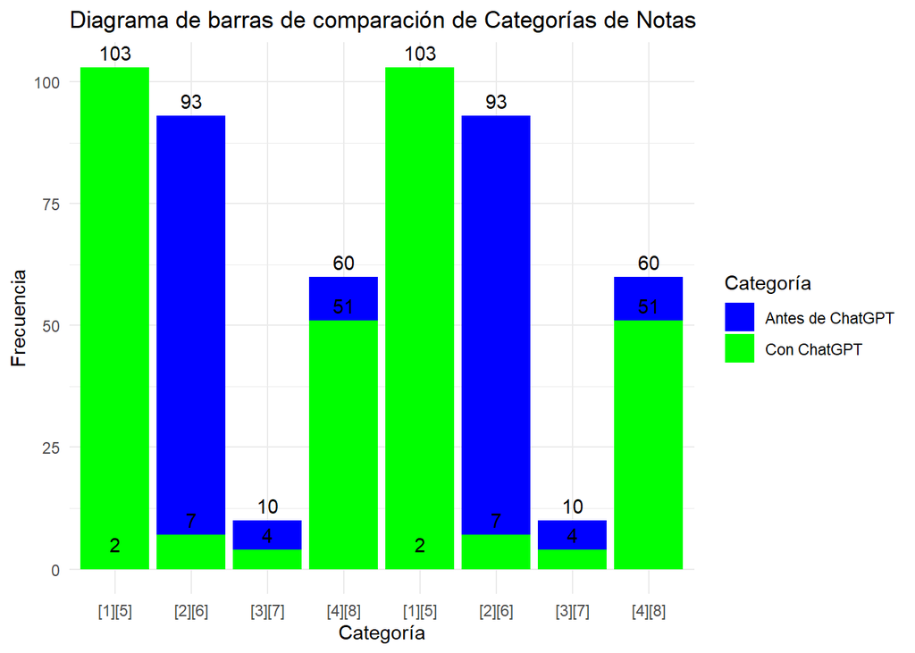

```r
# Gráfico de barras con etiquetas de cantidad
nombres <- c("[1][5]", "[2][6]", "[3][7]", "[4][8]", "[1][5]", "[2][6]", "[3][7]", "[4][8]")
ggplot(df, aes(x = Categoría)) +
  geom_bar(aes(y = Antes_ChatGPT, fill = "Antes de ChatGPT"), stat = "identity", position = "dodge") +
  geom_bar(aes(y = Con_ChatGPT, fill = "Con ChatGPT"), stat = "identity", position = "dodge") +
  labs(title = "Diagrama de barras de comparación de Categorías de Notas",
       x = "Categoría",
       y = "Frecuencia",
       fill = "Categoría") +scale_x_discrete(labels = nombres)+
  scale_fill_manual(values = c("blue", "green"),
                    labels = c("Antes de ChatGPT", "Con ChatGPT")) +
  geom_text(aes(y = Antes_ChatGPT, label = Antes_ChatGPT), vjust = -0.5, color = "black") +
  geom_text(aes(y = Con_ChatGPT, label = Con_ChatGPT), vjust = -0.5, color = "black") +
  theme_minimal()
```

*[1]=“Mis notas eran muy malas, no entrega tareas a tiempo.”* *[2]=“Mis notas eran regulares, hacia lo que podía.”* *[3]=“Mis notas estaban un poco bajas, a veces no me alcanzaba tiempo.”* *[4]=“Tenia muy buenas notas, estaba muy bien.”* *[5]=“Me va casi igual de antes que existiera, no hay mucha diferencia.”* *[6]=“Me va igual de mal.”* *[7]=“Me va mal a pesar de la existencia de "ChatGPT".”* *[8]=“Me va muy bien, hago mis tareas rápida y eficazmente.”*

```r
# Cargar el paquete "irr"
library(irr)

# Crear una matriz de clasificación
matriz_clasificacion <- matrix(c(DB4$Rendimiento_academico_SIN_ChatGPT, DB4$Notas_CON_ChatGPT), ncol = 2)

# Calcular el coeficiente de concordancia de Fleiss
kappa <- kappam.fleiss(matriz_clasificacion)$value

kappa
```

```
## [1] -0.3077625
```

El valor del coeficiente de concordancia de Fleiss obtenido (-0.3077625) indica una concordancia baja o negativa entre las categorías de notas antes y después de ChatGPT.

Un valor negativo sugiere que la concordancia observada es inferior a la concordancia esperada por azar, lo que implica una falta de acuerdo entre los evaluadores en la asignación de categorías.